## Xác định hàm liên kết chính tắc, hàm liên kết không chính tắc

Ta có:

$\hspace{2cm} f_Y(y_i) = exp\{y_i\theta_i - m_ilog(1+e^{\theta_i}) + log(C_{y_i}^{m_i}) \}$

$\hspace{2cm} \Leftrightarrow f_Y(y_i) = exp\{\frac{y_i}{m_i}\theta_i - log(1+e^{\theta_i}) + \frac{1}{m_i}log(C_{y_i}^{m_i}) \}$  
Đặt $Z_i = \frac{y_i}{m_i}$, ta có:

$\hspace{2cm} f_Z(z_i) = exp\{z_i\theta_i - log(1+e^{\theta_i}) + log(C_{y_i}^{z_im_i}) \}$

$\hspace{2cm}$ Với:

$\hspace{2cm}\theta_i = log(\frac{p_i}{1-p_i})$

$\hspace{2cm} b(\theta_i) = log(1+e^{\theta_i})$

$\hspace{2cm} a(\phi) = 1$

$\hspace{2cm} c(y_i,\phi) = log(C_{y_i}^{z_im_i})$

Tính kỳ vọng của Z:

$\hspace{2cm} E[z_i] = E\left[\frac{y_i}{m_i}\right] = \frac{m_ip_i}{m_i} = p_i$

$\hspace{2cm} E[z_i] = \frac{\partial}{\partial\theta_i}b(\theta_i)$

$\hspace{3cm} \Leftrightarrow E[z_i] = \frac{e^{\theta_i}}{1+e^{\theta_i}}$

$\mu = \frac{e^{\theta_i}}{1+e^{\theta_i}} = p_i \in [0,1]$

$\hspace{3cm} \Leftrightarrow E[y_i] = m_i\frac{e^{\theta_i}}{1+e^{\theta_i}}$

$\hspace{3cm} \Leftrightarrow E[y_i] = m_ip_i$ (Do **1.1**) **(3)**

Ta có:

$\hspace{2cm} \mu_i = E[y_i]$

$\hspace{3cm} \Leftrightarrow \mu_i = m_ip_i$ (Do **3**)

$\hspace{3cm} \Leftrightarrow p_i= \frac{\mu_i}{m_i}$

Mà:

$\hspace{2cm} \theta_i = log(\frac{p_i}{1-p_i})$

$\hspace{3cm} \Leftrightarrow \theta_i = log(\frac{\frac{\mu_i}{m_i}}{1-\frac{\mu_i}{m_i}})$

Vậy hàm liên kết chính tắc là $\theta_i = log(\frac{\frac{\mu_i}{m_i}}{1-\frac{\mu_i}{m_i}})$

Hàm liên kết khác:

Hàm $\theta = \frac{1}{1+e^{-mu}}$

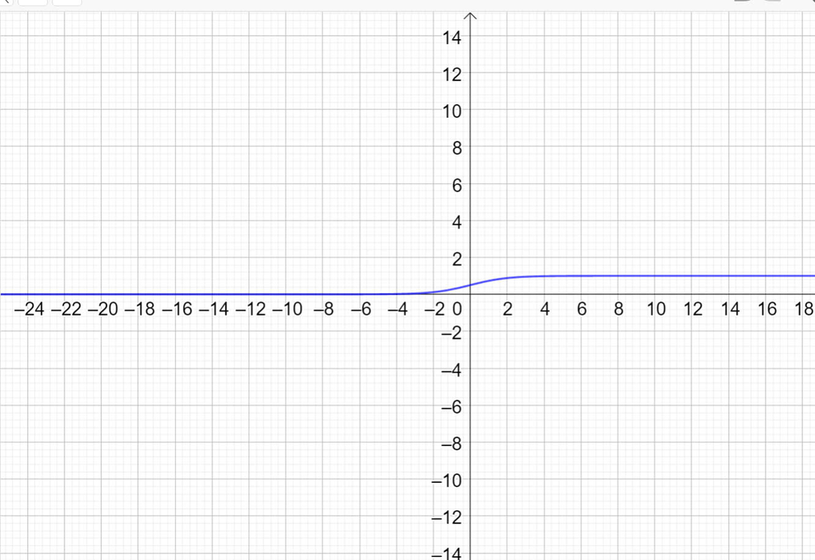

Hàm liên kết 1

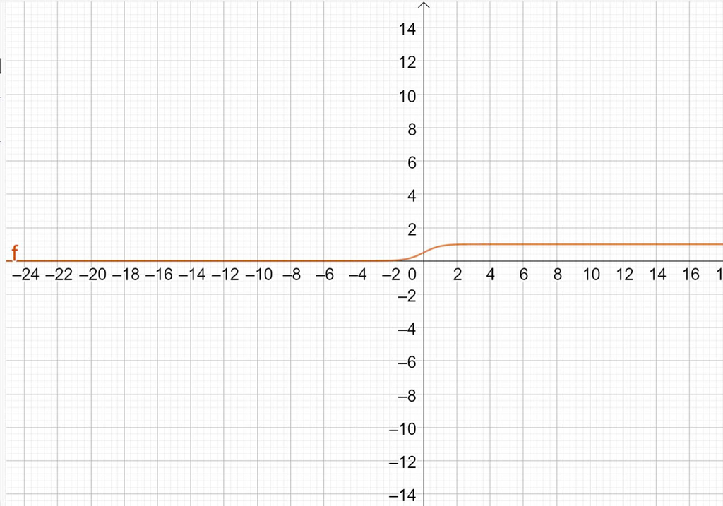

Hàm $theta = exp(-exp(-x))$

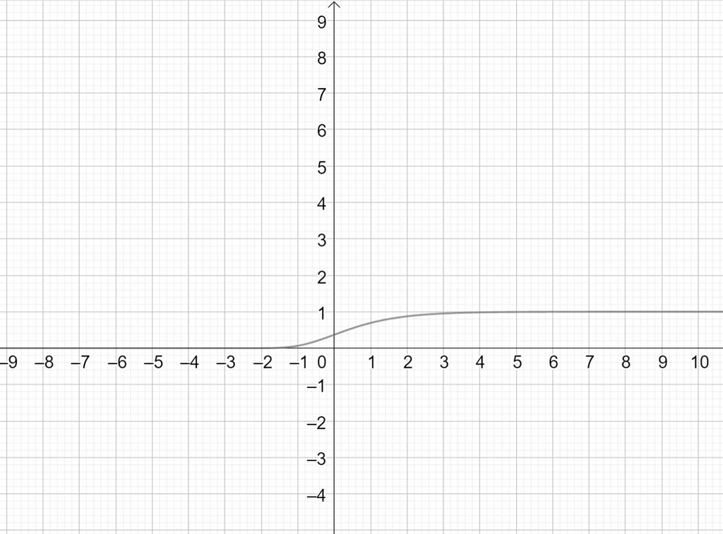

Hàm liên kết 3